# Análisis exploratorio de datos (EDA) - Proyecto Informalidad

Guillermo Coronado

2026-06-24

# **Introducción**

## I. Análisis Univariado: La Estructura de la Ocupación y la Vulnerabilidad

### 1. Inserción Laboral y Formalidad Empresarial

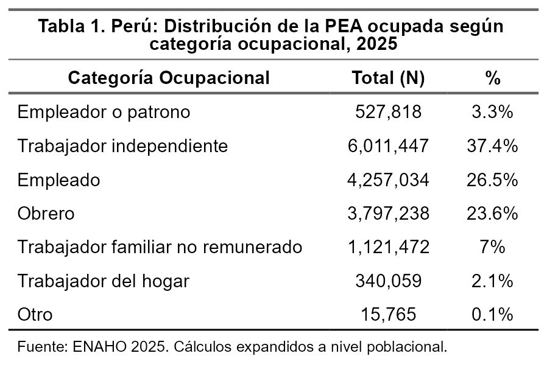

Tabla 1: Distribución por categoría ocupacional

La **Tabla 1** muestra que la estructura ocupacional peruana está fuertemente atomizada. La suma de las categorías de “Trabajador independiente” (37.4%) y de “Trabajador familiar no remunerado” (7%) revela una economía donde el autoempleo y las estrategias de supervivencia familiar prevalecen. La relación salarial clásica (empleados y obreros) representa apenas a la mitad de la PEA, lo que redefine las lógicas tradicionales de clase y capital en el país.

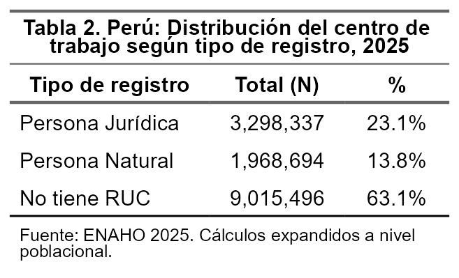

Tabla 2: Tipo de registro del centro de trabajo

En relación a la formalidad de los centros de trabajo, la **Tabla 2** muestra que la informalidad empresarial no es un fenómeno marginal, sino el núcleo del modelo económico. El 63.1% de los centros de trabajo opera sin RUC. Este dato es un indicador directo de la limitada capacidad del Estado para regular las unidades productivas, fiscalizar condiciones laborales y recaudar impuestos.

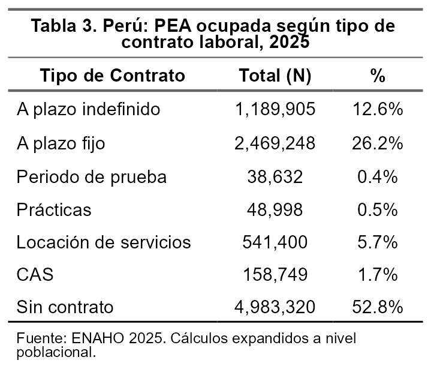

Tabla 3: Tipo de contrato laboral

La informalidad no solo se evidencia en la falta de registro formal de las empresas, sino que también se evidencia directamente entre los trabajadores. De esta manera, la **Tabla 3** muestra que un 52.8% de trabajadores opera bajo “Sin contrato”, lo que indica que la informalidad laboral es la norma en el país. Solo un 12.6% goza de contratos a plazo indefinido, lo que demuestra que la estabilidad laboral es un privilegio de muy pocos, dificultando la proyección económica a largo plazo de las familias.

### 2. Protección Social y Legitimidad Institucional

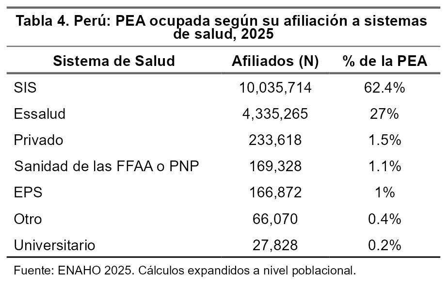

Tabla 4: Afiliación a sistemas de salud

En lo que respecta a los indicadores de protección social, la **Tabla 4** muestra que el mercado laboral no está proveyendo aseguramiento contributivo. El hecho de que el 62.4% dependa del Seguro Integral de Salud (SIS) evidencia que el Estado ha tenido que asumir el rol de asegurador universal ante la incapacidad del mercado laboral para integrar a los trabajadores a sistemas formales como Essalud (27%).

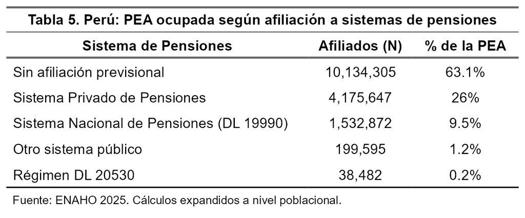

Tabla 5: Afiliación a sistemas de pensiones

La **Tabla 5**, por su parte, evidencia que esta baja cobertura de la protección social también se extiende al ámbito de las pensiones, ya que el 63.1% de la PEA ocupada no está afiliada a ningún sistema de pensiones. Esto significa que dos tercios de la fuerza laboral actual enfrentarán su vejez sin un ingreso de reemplazo, lo que augura un incremento drástico de la pobreza en la tercera edad durante las próximas décadas.

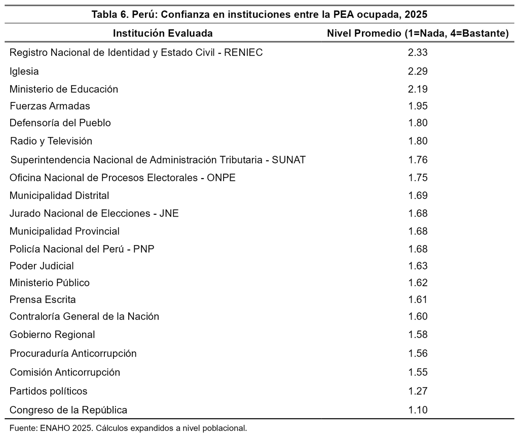

Tabla 6: Ranking de confianza en instituciones

Finalmente, la **Tabla 6** muestra que existe una desafección política generalizada. En una escala donde 1 es “Nada” y 4 es “Bastante”, casi todas las instituciones reprueban. Entidades clave para la democracia representativa, como los Partidos Políticos (1.27) y el Congreso de la República (1.10), muestran niveles críticos. Esto revela una profunda desconexión entre el ciudadano trabajador y el aparato estatal.

### 3. Perfil Demográfico, Bienestar y Discapacidades

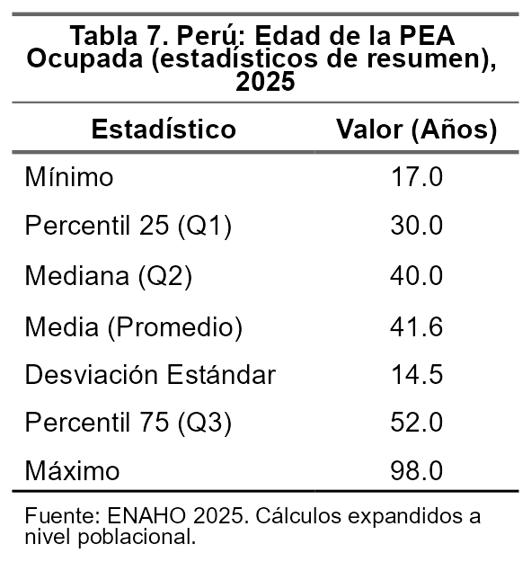

Tabla 7: Estadísticos de resumen - Edad

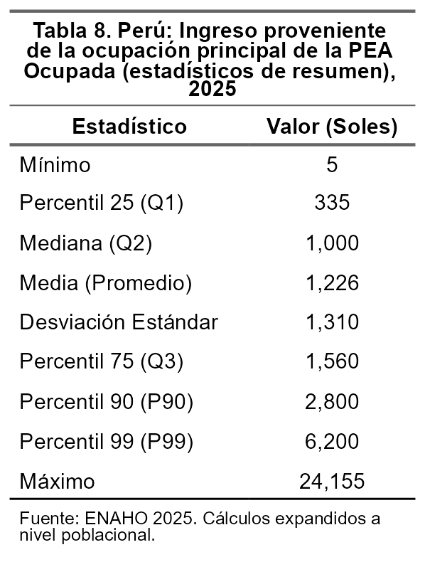

Tabla 8: Estadísticos de resumen - Ingreso Principal

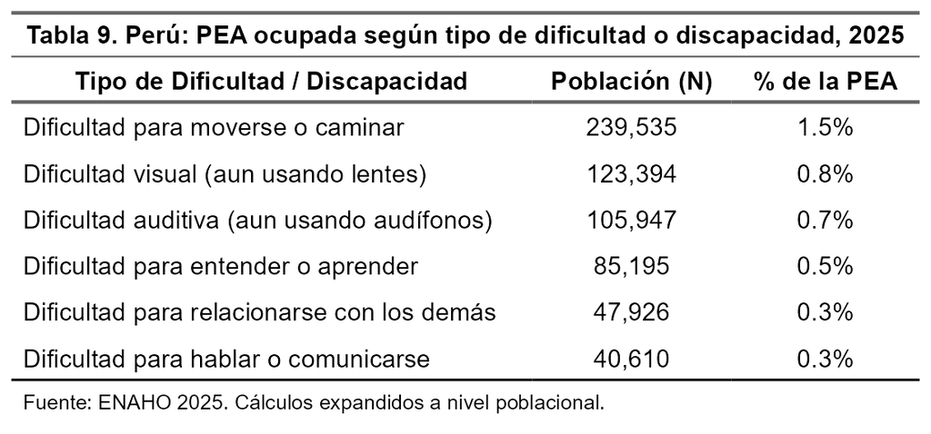

Tabla 9: Tipos de dificultad o discapacidad

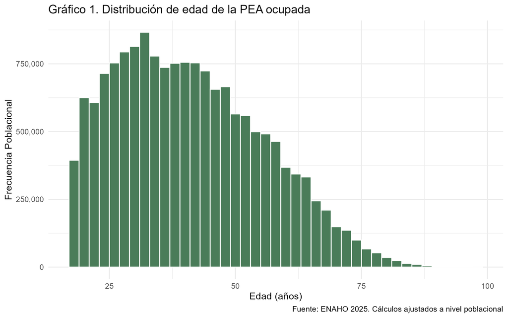

Gráfico 1: Distribución de edad de la PEA ocupada

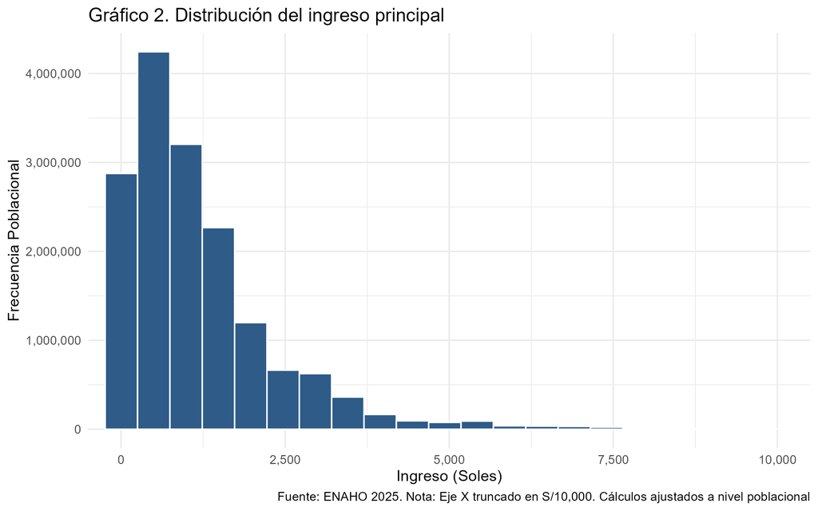

Gráfico 2: Distribución del ingreso principal

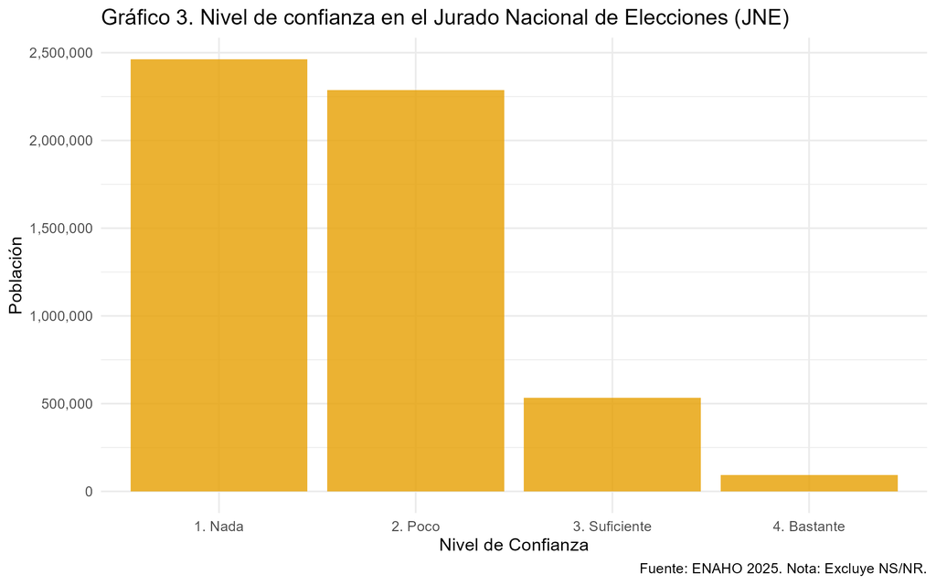

Gráfico 3: Confianza en el Jurado Nacional de Elecciones

Las **Tablas 7, 8 y 9** y los **Gráficos 1, 2 y 3** muestran que la fuerza laboral tiene una mediana de edad de 40 años, indicando cierta madurez demográfica, lo que se alinea con el hecho de que el Perú se encuentra en una etapa de culminación del bono demográfico. Por su parte, los ingresos exhiben una desigualdad abrumadora: mientras la mediana es de S/ 1,000, un pequeño grupo (el percentil 99) percibe S/ 6,200 o más. La alta dispersión (Desviación Estándar = S/ 1,310) confirma que no existe un trabajador “típico”.

A esto se suma la vulnerabilidad física (Tabla 9): aunque las dificultades motrices o visuales representan porcentajes menores, en un mercado altamente informal, estas personas enfrentan dobles barreras de exclusión. Finalmente, el Gráfico 3 ilustra visualmente la asimetría en la legitimidad del árbitro electoral, dominada por los niveles “Nada” y “Poco”.

## II. Análisis Bivariado: Relaciones Estructurales y Brechas

### Segregación y Brechas de Género

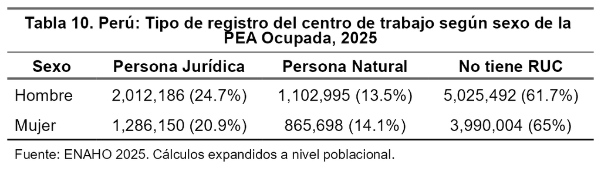

Tabla 10: Tipo de registro del centro de trabajo según sexo

La **Tabla 10** muestra que la inserción en el mercado laboral informal tiene un claro sesgo de género. El 65% de las mujeres labora en centros de trabajo sin RUC, en comparación con el 61.7% de los hombres. Esta diferencia estructural condena a una mayor proporción de mujeres a entornos desprovistos de beneficios sociales y licencias de maternidad.

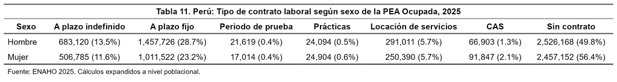

Tabla 11: Tipo de contrato laboral según sexo

La **Tabla 11**, pos su parte, muestra que, al observar a los trabajadores dependientes, la precarización contractual castiga desproporcionadamente a la fuerza laboral femenina. El 56.4% de las mujeres trabaja sin contrato, superando al 49.8% de los hombres. El mercado laboral actúa aquí como un amplificador de la vulnerabilidad económica femenina.

### La formalidad, el ingreso y la desconfianza en las instituciones

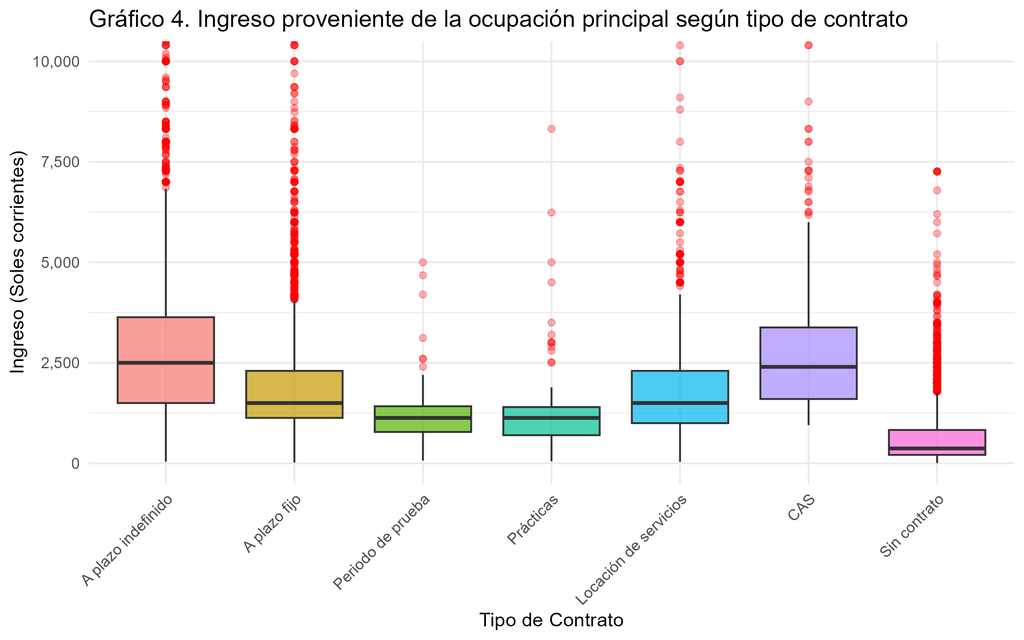

Gráfico 4: Ingreso proveniente de la ocupación principal según tipo de contrato

El **Gráfico 4** muestra que la formalidad jurídica tiene un premio salarial evidente. Los trabajadores con contratos a plazo indefinido concentran las medianas y distribuciones de ingreso más altas. En contraste, las categorías “Sin contrato” operan no solo en la desprotección legal, sino como una verdadera trampa de bajos ingresos.

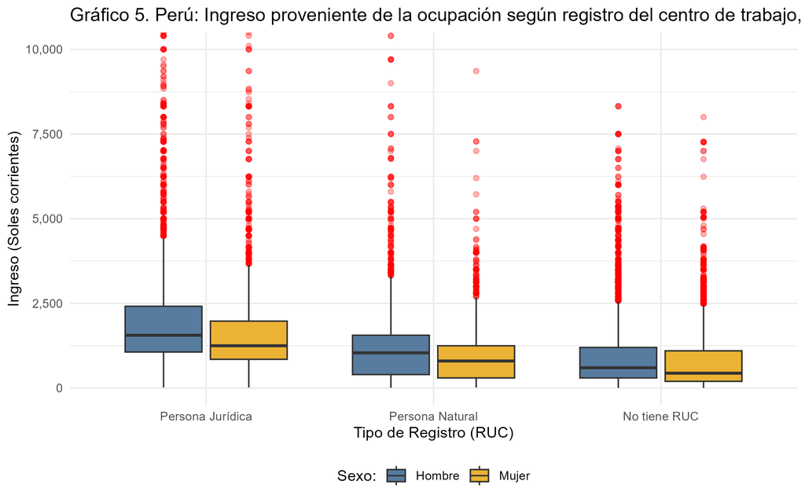

Gráfico 5: Ingreso según registro del centro de trabajo y sexo

El **Gráfico 5** muestra que la formalización empresarial no borra las brechas de género. Incluso dentro del sector más estructurado (“Persona Jurídica”), las cajas azules (hombres) se ubican consistentemente por encima de las cajas amarillas (mujeres). La penalización salarial hacia las mujeres persiste transversalmente, demostrando que la desigualdad es interseccional.

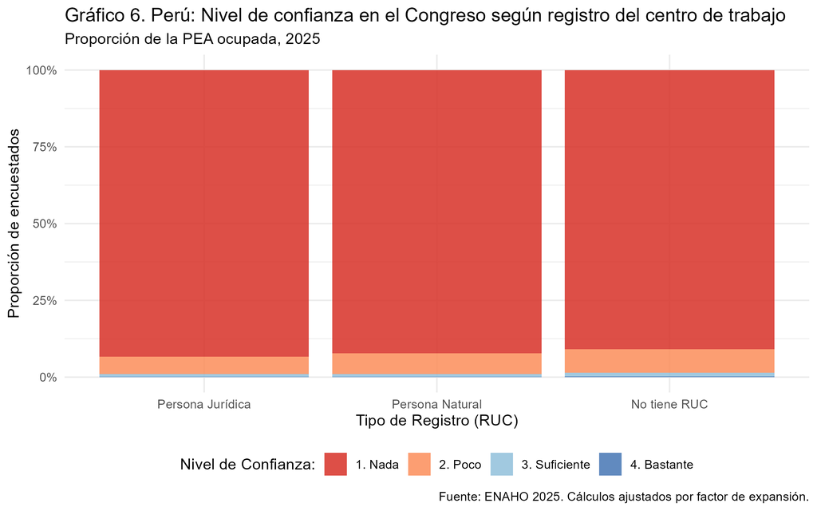

Gráfico 6: Nivel de confianza en el Congreso según registro del centro de trabajo

En contraste con lo que sucede en los gráficos anteriores, el **Gráfico 6** no muestra una relación clara entre la formalidad y la confianza en las instituciones. En otras palabras, la desconfianza no distingue estratos laborales. El abrumador color rojo (“1. Nada”) domina por igual entre trabajadores de grandes empresas y aquellos en la informalidad total. La inserción formal en la economía no está integrando a los ciudadanos a un pacto social democrático sólido.

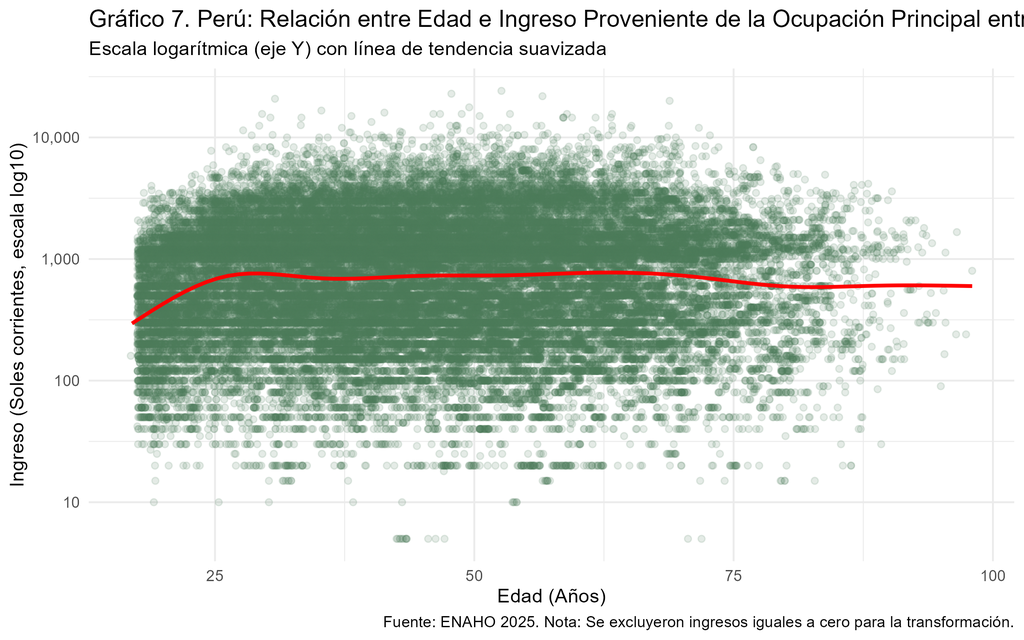

Gráfico 7: Relación entre Edad e Ingreso Principal